# Prediction Assignment Writeup

Henglong Luo

Aug 30, 2018

This file is created for the final report of the Peer Assessment project of Coursera’s MOOC Practical Machine Learning from Johns Hopkins University.

The scripts have been solely produced, tested and executed on i386-w64-mingw32/i386 (32-bit), and R Version 3.4.3.

# Background

Using devices such as Jawbone Up, Nike FuelBand, and Fitbit it is now possible to collect a large amount of data about personal activity relatively inexpensively. These type of devices are part of the quantified self movement – a group of enthusiasts who take measurements about themselves regularly to improve their health, to find patterns in their behavior, or because they are tech geeks. One thing that people regularly do is quantify how much of a particular activity they do, but they rarely quantify how well they do it. In this project, your goal will be to use data from accelerometers on the belt, forearm, arm, and dumbell of 6 participants. They were asked to perform barbell lifts correctly and incorrectly in 5 different ways. More information is available from the website here: (http://web.archive.org/web/20161224072740/http:/groupware.les.inf.puc-rio.br/har) (see the section on the Weight Lifting Exercise Dataset).

The goal of your project is to predict the manner in which they did the exercise. This is the “classe” variable in the training set. You may use any of the other variables to predict with. You should create a report describing how you built your model, how you used cross validation, what you think the expected out of sample error is, and why you made the choices you did. You will also use your prediction model to predict 20 different test cases.

# Data

The training data for this project are available here:

(https://d396qusza40orc.cloudfront.net/predmachlearn/pml-training.csv)

The test data are available here:

(https://d396qusza40orc.cloudfront.net/predmachlearn/pml-testing.csv)

The data for this project come from this source: (http://web.archive.org/web/20161224072740/http:/groupware.les.inf.puc-rio.br/har). If you use the document you create for this class for any purpose please cite them as they have been very generous in allowing their data to be used for this kind of assignment.

# Load and Clean Data

## Install Packages and Upload Libraries

[output not shown]

## Load data

```r
rm(list=ls())    #clean global environment
dirin <- getwd() #get current working directory. If you put the downloaded data and the R script file in the same folder, you can import data directly like this
UrlTrain <- read.csv("pml-training.csv")  #import training data from files downloaded and saved in computer
UrlTest  <- read.csv("pml-testing.csv")   #import testing  data from files downloaded and saved in computer
dim(UrlTrain);dim(UrlTest)
```

```
## [1] 19622   160
```

```
## [1]  20 160
```

## Split training set into myTraining set and myTesting set

The testing data set containing 20 cases, which was named as UrlTest, is to test the finally selected model. To select the optimal model, we need to split training data set, which was named as UrlTrain into two sets, one for modeling and the other for validting. I named them as myTraining and myTesting respectively.

```r
inTrain <- createDataPartition(y=UrlTrain$classe, p=0.7, list=FALSE)
myTraining <- UrlTrain[inTrain, ]
myTesting  <- UrlTrain[-inTrain, ]
dim(myTraining)
```

```
## [1] 13737   160
```

```r
dim(myTesting)
```

```
## [1] 5885  160
```

## Clean data

Results of the previous steps show there are 160 variables, with 159 predictors and 1 variable to predict. For the 159 predictors, many of them are not meaningful in modeling either becase there are lots of NA in the variables or because they are the Near Zero variance (NZV) variables. Meanwhile, the first five variables are identifers, which should not have predictability either. Thus, I remove these variables by the following steps.

```r
NZV <- nearZeroVar(myTraining)
myTraining <- myTraining[, -NZV] # remove Near Zeor variance Variables
myTesting  <- myTesting[, -NZV] # remove Near Zeor variance Variables
AllNA      <- sapply(myTraining, function(x) mean(is.na(x))) > 0.95
myTraining <- myTraining[, AllNA==FALSE] # Remove NA variables
myTesting  <- myTesting[, AllNA==FALSE] # Remove NA variables
myTraining <- myTraining[, -(1:5)] #Remove the variables for identification (Column 1 to 5)
myTesting  <- myTesting[, -(1:5)] #Remove the variables for identification (Column 1 to 5)
dim(myTraining)
```

```
## [1] 13737    54
```

```r
dim(myTesting)
```

```
## [1] 5885   54
```

# Correlation Analysis

Here I attempt to explore the correlation between predictors. If there is high correlation, data preprocessing, in particular Principal Components Analysis (PCA), may be required.

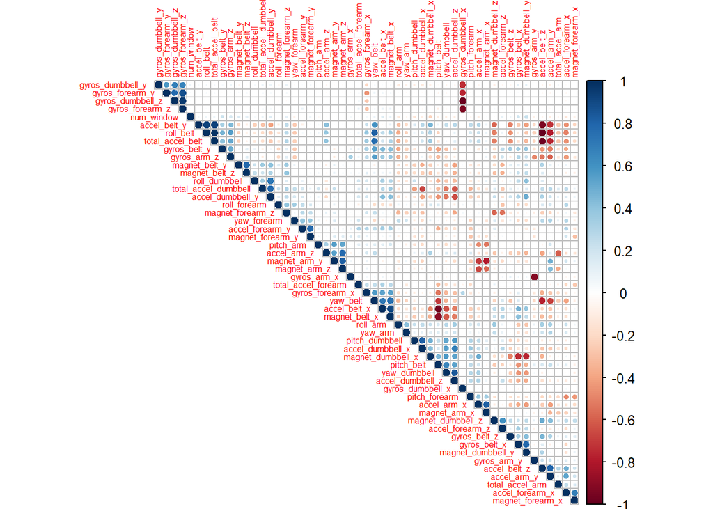

```r
corMatrix <- cor(myTraining[, -54]) #create correlation matrix including all predictors
par(mar=c(1,1,1,1))                 #set layout parameters for plotting
corrplot(corMatrix, order = "hclust" , type = "upper",tl.cex = 0.5) #plot the correlation
```

The plot shows there exists high correlation between some variables, indicated by dark colours. I further confirm this by identifying the specific variables.

```r
M <- abs(corMatrix)
diag(M) <-0
which(M >.9,arr.ind = T) # variables with high correlation.
```

```
##                  row col
## total_accel_belt   5   2
## accel_belt_y      10   2
## accel_belt_z      11   2
## accel_belt_x       9   3
## roll_belt          2   5
## accel_belt_y      10   5
## accel_belt_z      11   5
## pitch_belt         3   9
## magnet_belt_x     12   9
## roll_belt          2  10
## total_accel_belt   5  10
## accel_belt_z      11  10
## roll_belt          2  11
## total_accel_belt   5  11
## accel_belt_y      10  11
## accel_belt_x       9  12
## gyros_arm_y       20  19
## gyros_arm_x       19  20
## gyros_dumbbell_z  34  32
## gyros_forearm_z   47  32
## gyros_dumbbell_x  32  34
## gyros_forearm_z   47  34
## gyros_dumbbell_x  32  47
## gyros_dumbbell_z  34  47
```

Thus, I will use PCA to conduct data preprocessing for each modeling method and compare the accuracy between model without PCA and model with PCA.

# Prediction models

## Random Forest

```r
set.seed(12345)
controlRF          <- trainControl(method="cv", number=3, verboseIter=FALSE)
modFitRandForest   <- train(classe ~ ., data=myTraining, method="rf", trControl=controlRF)
modFitRandForestPC <- train(classe ~ ., method="rf",preProcess="pca", data=myTraining, trControl=controlRF)
modFitRandForest$finalModel
```

```
##
## Call:
##  randomForest(x = x, y = y, mtry = param$mtry)
##                Type of random forest: classification
##                      Number of trees: 500
## No. of variables tried at each split: 27
##
##         OOB estimate of  error rate: 0.24%
## Confusion matrix:
##      A    B    C    D    E  class.error
## A 3905    0    0    0    1 0.0002560164
## B    8 2647    2    1    0 0.0041384500
## C    0    7 2388    1    0 0.0033388982
## D    0    0    8 2244    0 0.0035523979
## E    0    0    0    5 2520 0.0019801980
```

```r
modFitRandForestPC$finalModel
```

```
##
## Call:
##  randomForest(x = x, y = y, mtry = param$mtry)
##                Type of random forest: classification
##                      Number of trees: 500
## No. of variables tried at each split: 2
##
##         OOB estimate of  error rate: 2.35%
## Confusion matrix:
##      A    B    C    D    E class.error
## A 3873   11   15    5    2 0.008448541
## B   38 2577   37    2    4 0.030474041
## C    4   40 2333   19    0 0.026293823
## D    2    5   96 2143    6 0.048401421
## E    1    8   13   15 2488 0.014653465
```

### prediction on myTesting set

```r
predictRandForest   <- predict(modFitRandForest  , newdata=myTesting)
predictRandForestPC <- predict(modFitRandForestPC, newdata=myTesting)
confMatRandForest   <- confusionMatrix(predictRandForest  , myTesting$classe)
confMatRandForestPC <- confusionMatrix(predictRandForestPC, myTesting$classe)
confMatRandForest
```

```
## Confusion Matrix and Statistics
##
##           Reference
## Prediction    A    B    C    D    E
##          A 1673    3    0    0    0
##          B    1 1136    1    0    0
##          C    0    0 1025    5    0
##          D    0    0    0  958    3
##          E    0    0    0    1 1079
##
## Overall Statistics
##
##                Accuracy : 0.9976
##                  95% CI : (0.996, 0.9987)
##     No Information Rate : 0.2845
##     P-Value [Acc > NIR] : < 2.2e-16
##
##                   Kappa : 0.997
##  Mcnemar's Test P-Value : NA
##
## Statistics by Class:
##
##                      Class: A Class: B Class: C Class: D Class: E
## Sensitivity            0.9994   0.9974   0.9990   0.9938   0.9972
## Specificity            0.9993   0.9996   0.9990   0.9994   0.9998
## Pos Pred Value         0.9982   0.9982   0.9951   0.9969   0.9991
## Neg Pred Value         0.9998   0.9994   0.9998   0.9988   0.9994
## Prevalence             0.2845   0.1935   0.1743   0.1638   0.1839
## Detection Rate         0.2843   0.1930   0.1742   0.1628   0.1833
## Detection Prevalence   0.2848   0.1934   0.1750   0.1633   0.1835
## Balanced Accuracy      0.9993   0.9985   0.9990   0.9966   0.9985
```

```r
confMatRandForestPC
```

```
## Confusion Matrix and Statistics
##
##           Reference
## Prediction    A    B    C    D    E
##          A 1661   23    1    1    0
##          B    4 1100   16    0    0
##          C    7   15 1004   39   10
##          D    1    0    3  924   10
##          E    1    1    2    0 1062
##
## Overall Statistics
##
##                Accuracy : 0.9772
##                  95% CI : (0.9731, 0.9809)
##     No Information Rate : 0.2845
##     P-Value [Acc > NIR] : < 2.2e-16
##
##                   Kappa : 0.9712
##  Mcnemar's Test P-Value : NA
##
## Statistics by Class:
##
##                      Class: A Class: B Class: C Class: D Class: E
## Sensitivity            0.9922   0.9658   0.9786   0.9585   0.9815
## Specificity            0.9941   0.9958   0.9854   0.9972   0.9992
## Pos Pred Value         0.9852   0.9821   0.9340   0.9851   0.9962
## Neg Pred Value         0.9969   0.9918   0.9954   0.9919   0.9958
## Prevalence             0.2845   0.1935   0.1743   0.1638   0.1839
## Detection Rate         0.2822   0.1869   0.1706   0.1570   0.1805
## Detection Prevalence   0.2865   0.1903   0.1827   0.1594   0.1811
## Balanced Accuracy      0.9931   0.9808   0.9820   0.9778   0.9903
```

## Decision Tree

[figure not shown]

```r
set.seed(12345)
modFitDecTree   <- train(classe ~ ., data=myTraining, method="rpart")
modFitDecTreePC <- train(classe ~ ., method="rpart", preProcess="pca", data=myTraining)
fancyRpartPlot(modFitDecTree$finalModel)
```

[figure not shown]

```r
fancyRpartPlot(modFitDecTreePC$finalModel)
```

```r
modFitDecTree$finalModel
```

```
## n= 13737
##
## node), split, n, loss, yval, (yprob)
##       * denotes terminal node
##
##  1) root 13737 9831 A (0.28 0.19 0.17 0.16 0.18)
##    2) roll_belt< 130.5 12563 8668 A (0.31 0.21 0.19 0.18 0.11)
##      4) pitch_forearm< -33.05 1147   14 A (0.99 0.012 0 0 0) *
##      5) pitch_forearm>=-33.05 11416 8654 A (0.24 0.23 0.21 0.2 0.12)
##       10) magnet_dumbbell_y< 425.5 9461 6774 A (0.28 0.18 0.24 0.19 0.1)
##         20) roll_forearm< 121.5 5858 3452 A (0.41 0.18 0.19 0.17 0.057) *
##         21) roll_forearm>=121.5 3603 2403 C (0.078 0.18 0.33 0.23 0.18) *
##       11) magnet_dumbbell_y>=425.5 1955  988 B (0.038 0.49 0.049 0.22 0.2) *
##    3) roll_belt>=130.5 1174   11 E (0.0094 0 0 0 0.99) *
```

```r
modFitDecTreePC$finalModel
```

```
## n= 13737
##
## node), split, n, loss, yval, (yprob)
##       * denotes terminal node
##
## 1) root 13737 9831 A (0.28 0.19 0.17 0.16 0.18)
##   2) PC3>=0.2109684 6986 4220 A (0.4 0.16 0.21 0.11 0.13) *
##   3) PC3< 0.2109684 6751 5131 E (0.17 0.23 0.14 0.22 0.24)
##     6) PC13>=-0.3882028 4590 3205 B (0.18 0.3 0.17 0.2 0.15) *
##     7) PC13< -0.3882028 2161 1244 E (0.14 0.078 0.085 0.27 0.42) *
```

### Prediction on myTesting set

```r
predictDecTree   <- predict(modFitDecTree  , newdata=myTesting)
predictDecTreePC <- predict(modFitDecTreePC, newdata=myTesting)
confMatDecTree   <- confusionMatrix(predictDecTree  , myTesting$classe)
confMatDecTreePC <- confusionMatrix(predictDecTreePC, myTesting$classe)
confMatDecTree
```

```
## Confusion Matrix and Statistics
##
##           Reference
## Prediction    A    B    C    D    E
##          A 1499  472  460  414  158
##          B   52  387   39  188  151
##          C  120  280  527  362  305
##          D    0    0    0    0    0
##          E    3    0    0    0  468
##
## Overall Statistics
##
##                Accuracy : 0.4895
##                  95% CI : (0.4767, 0.5024)
##     No Information Rate : 0.2845
##     P-Value [Acc > NIR] : < 2.2e-16
##
##                   Kappa : 0.3337
##  Mcnemar's Test P-Value : NA
##
## Statistics by Class:
##
##                      Class: A Class: B Class: C Class: D Class: E
## Sensitivity            0.8955  0.33977  0.51365   0.0000  0.43253
## Specificity            0.6428  0.90940  0.78041   1.0000  0.99938
## Pos Pred Value         0.4992  0.47368  0.33061      NaN  0.99363
## Neg Pred Value         0.9393  0.85162  0.88371   0.8362  0.88659
## Prevalence             0.2845  0.19354  0.17434   0.1638  0.18386
## Detection Rate         0.2547  0.06576  0.08955   0.0000  0.07952
## Detection Prevalence   0.5103  0.13883  0.27086   0.0000  0.08003
## Balanced Accuracy      0.7692  0.62458  0.64703   0.5000  0.71595
```

```r
confMatDecTreePC
```

```
## Confusion Matrix and Statistics
##
##           Reference
## Prediction    A    B    C    D    E
##          A 1152  455  593  314  422
##          B  381  606  364  398  286
##          C    0    0    0    0    0
##          D    0    0    0    0    0
##          E  141   78   69  252  374
##
## Overall Statistics
##
##                Accuracy : 0.3623
##                  95% CI : (0.35, 0.3747)
##     No Information Rate : 0.2845
##     P-Value [Acc > NIR] : < 2.2e-16
##
##                   Kappa : 0.1638
##  Mcnemar's Test P-Value : NA
##
## Statistics by Class:
##
##                      Class: A Class: B Class: C Class: D Class: E
## Sensitivity            0.6882   0.5320   0.0000   0.0000  0.34566
## Specificity            0.5763   0.6989   1.0000   1.0000  0.88757
## Pos Pred Value         0.3924   0.2978      NaN      NaN  0.40919
## Neg Pred Value         0.8230   0.8616   0.8257   0.8362  0.85757
## Prevalence             0.2845   0.1935   0.1743   0.1638  0.18386
## Detection Rate         0.1958   0.1030   0.0000   0.0000  0.06355
## Detection Prevalence   0.4989   0.3458   0.0000   0.0000  0.15531
## Balanced Accuracy      0.6323   0.6155   0.5000   0.5000  0.61661
```

## Generalized Boosted Model

```r
set.seed(12345)
controlGBM   <- trainControl(method = "repeatedcv", number = 5, repeats = 1)
modFitGBM    <- train(classe ~ ., data=myTraining, method = "gbm",
                    trControl = controlGBM, verbose = FALSE)
modFitGBMPC  <- train(classe ~ ., data=myTraining, method = "gbm",preProcess="pca",
                    trControl = controlGBM, verbose = FALSE)
modFitGBM$finalModel
```

```
## A gradient boosted model with multinomial loss function.
## 150 iterations were performed.
## There were 53 predictors of which 41 had non-zero influence.
```

```r
modFitGBMPC$finalModel
```

```
## A gradient boosted model with multinomial loss function.
## 150 iterations were performed.
## There were 25 predictors of which 25 had non-zero influence.
```

### Prediction on myTesting set

```r
predictGBM    <- predict(modFitGBM  , newdata=myTesting)
predictGBMPC  <- predict(modFitGBMPC, newdata=myTesting)
confMatGBM    <- confusionMatrix(predictGBM  , myTesting$classe)
confMatGBMPC  <- confusionMatrix(predictGBMPC, myTesting$classe)
confMatGBM
```

```
## Confusion Matrix and Statistics
##
##           Reference
## Prediction    A    B    C    D    E
##          A 1671   11    0    0    0
##          B    3 1120   11    5    6
##          C    0    8 1014    6    0
##          D    0    0    1  953    8
##          E    0    0    0    0 1068
##
## Overall Statistics
##
##                Accuracy : 0.99
##                  95% CI : (0.9871, 0.9924)
##     No Information Rate : 0.2845
##     P-Value [Acc > NIR] : < 2.2e-16
##
##                   Kappa : 0.9873
##  Mcnemar's Test P-Value : NA
##
## Statistics by Class:
##
##                      Class: A Class: B Class: C Class: D Class: E
## Sensitivity            0.9982   0.9833   0.9883   0.9886   0.9871
## Specificity            0.9974   0.9947   0.9971   0.9982   1.0000
## Pos Pred Value         0.9935   0.9782   0.9864   0.9906   1.0000
## Neg Pred Value         0.9993   0.9960   0.9975   0.9978   0.9971
## Prevalence             0.2845   0.1935   0.1743   0.1638   0.1839
## Detection Rate         0.2839   0.1903   0.1723   0.1619   0.1815
## Detection Prevalence   0.2858   0.1946   0.1747   0.1635   0.1815
## Balanced Accuracy      0.9978   0.9890   0.9927   0.9934   0.9935
```

```r
confMatGBMPC
```

```
## Confusion Matrix and Statistics
##
##           Reference
## Prediction    A    B    C    D    E
##          A 1481   96   56   23   26
##          B   46  877   84   44   65
##          C   54  112  853  116   82
##          D   87   31   23  752   40
##          E    6   23   10   29  869
##
## Overall Statistics
##
##                Accuracy : 0.8211
##                  95% CI : (0.811, 0.8308)
##     No Information Rate : 0.2845
##     P-Value [Acc > NIR] : < 2.2e-16
##
##                   Kappa : 0.7737
##  Mcnemar's Test P-Value : < 2.2e-16
##
## Statistics by Class:
##
##                      Class: A Class: B Class: C Class: D Class: E
## Sensitivity            0.8847   0.7700   0.8314   0.7801   0.8031
## Specificity            0.9523   0.9496   0.9251   0.9632   0.9858
## Pos Pred Value         0.8805   0.7858   0.7009   0.8060   0.9274
## Neg Pred Value         0.9541   0.9451   0.9629   0.9572   0.9570
## Prevalence             0.2845   0.1935   0.1743   0.1638   0.1839
## Detection Rate         0.2517   0.1490   0.1449   0.1278   0.1477
## Detection Prevalence   0.2858   0.1896   0.2068   0.1585   0.1592
## Balanced Accuracy      0.9185   0.8598   0.8782   0.8717   0.8945
```

# Select the optimal model

Based on the accuracy in previous confusion matrices, we can see that for a given modeling method, model without PCA is better than with PCA. By comparing models without PCA in the three methods, Random Forest has the highest accuracy. Thus, **the model generated by Random Forest without PCA** is selected to predict the 20-case testing set.

# Apply the optimal model to the 20-case testing set

```r
predictOPTIMAL  <- predict(modFitRandForest, newdata=UrlTest)
predictOPTIMAL
```

```
##  [1] B A B A A E D B A A B C B A E E A B B B
## Levels: A B C D E
```

Thus, we got the predictions by applying our optimal model to the testing set.